# 9-1-2 checks

Katie Uzzell

02/03/2023

## 9-1-2 update summary

Data for 2011 to 2021 have been created and saved as 2023-03-03_9-1-2.csv in the 9-1-2 Output folder.

## Check configurations

Please check that the information below is as you expect. In particular, pay attention to the time since data were saved, to check that previously downloaded data have not accidentally been used.

These settings can all be adjusted in `config.R`

Files used to create the new data were downloaded and saved in 9-1-2/Example_Input.

#### **Aviation statistics from Department for Transport (DfT) and Civil Aviation Authority (CAA)**

Freight and passenger data are from the file avi0102.xlsx.

This file was saved at 2023-03-03 10:45:42: It has been 0.1 days since the file was saved in Example_Input

The tabs used are called TSGB0202g (freight data) and TSGB0202d (passenger data).

## Check data

The charts below show the new data (just created) plotted on top of the old data, which has been downloaded from the live site. If there are unexpected discrepancies in the lines please investigate the reasons for these discrepancies.

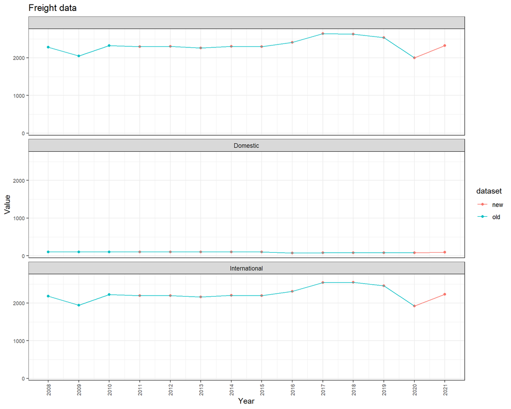

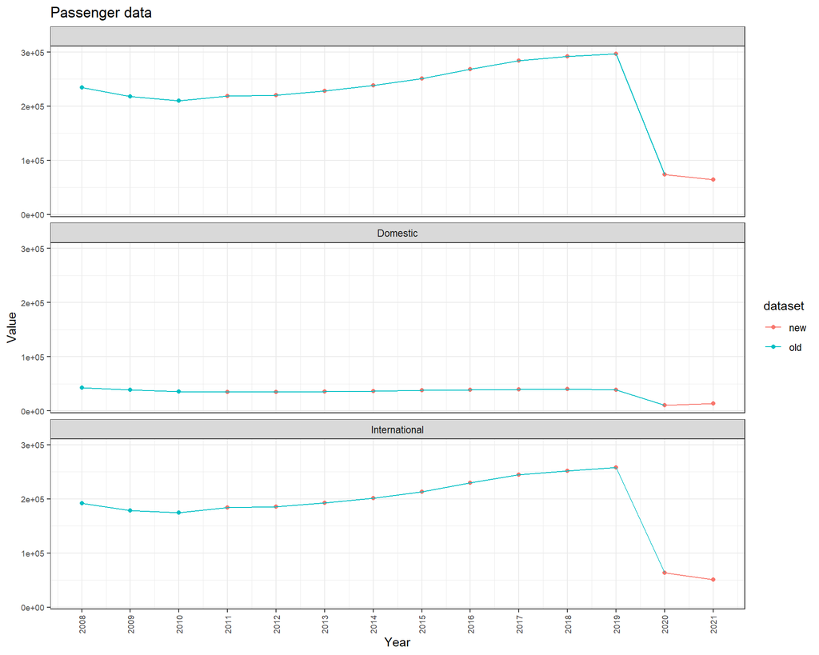

## Calculations

No calculations were performed on this data.